# CSCI E-63C Week 8 Problem Set

# Problem 3: stability of hierarchical clustering (15 points)

For top 2, 3 and 4 clusters (as obtained by `cutree` at corresponding levels of `k`) found by Ward method in `hclust` and by K-means when applied to the scaled WHS data compare cluster memberships between these two methods and describe their concordance. This problem is similar to the one from week 6 problem set, but this time it is *required* to: 1) use two dimensional contingency tables implemented by `table` to compare membership between two assignments of observations to clusters, and 2) programmatically re-order rows and columns in the `table` outcome in the increasing order of observations shared between two clusters (please see examples in lecture slides).

```r
# sort matrix function from lecture
matrix.sort = function(m){
  require(clue)
  p = solve_LSAP(m, maximum=T)
  m[,p]
}

hc.ward = hclust(dist(whs.data.scaled), method="ward.D2")

# contingency table function from lecture
cmp.shortcut = function(K, ...){
  matrix.sort(table(
    KMEANS = kmeans(whs.data.scaled, K, ...)$cluster,
    HCWARD = cutree(hc.ward, K)
  ))
}
cmp.shortcut(2, nstart=100)
```

```
##       HCWARD
## KMEANS   2   1
##      1 131   4
##      2   8  51
```

```r
cmp.shortcut(3, nstart=100)
```

```
##       HCWARD
## KMEANS  1  3  2
##      1 49  0  4
##      2  0 36 15
##      3  6  1 83
```

```r
cmp.shortcut(4, nstart=100)
```

```
##       HCWARD
## KMEANS  4  2  3  1
##      1 33 13  0  0
##      2  4 81  0  3
##      3  0  0 21  0
##      4  0  8 13 18
```

Above we have the contingency tables that compare results from cutree and kmeans for 2, 3, and 4 clusters. At each table, the clusters have very comparable results for cluster size and distribution when clustering the scaled WHS dataset. We want to look at the diagovnal for each table to see the distribution of observations for each cluster. For K=2 cluster size, we see that one cluster contains a third of the points and the other contains two thirds, in both KMEANS and HIERARCHICAL. At K=3 cluster size, the addition of of another cluster seems to split the two-thrids size cluster into one smaller and one larger. Look at how the sum of clusters 3+2 (HCWARD) / 2+3 (KMEANS) for K=3 has almost the same number of observations as cluster 2 for K=2. Finally at K=4 we see another split of a cluster so that we have one large cluster and three moderatly sized clusters in the WHS dataset for KMEANS and HIERARCHICAL clustering.

```r
# contingency tables for Quakes data
hc.ward2 = hclust(dist(quakes), method="ward.D2")

cmp.shortcut2 = function(K, ...){
  matrix.sort(table(
    KMEANS = kmeans(quakes, K, ...)$cluster,
    HCWARD = cutree(hc.ward2, K)
  ))
}
cmp.shortcut2(2, nstart=100)
```

```
##       HCWARD
## KMEANS   1   2
##      1 371  60
##      2   0 569
```

```r
cmp.shortcut2(3, nstart=100)
```

```
##       HCWARD
## KMEANS   1   3   2
##      1 371  16   0
##      2   0 200  24
##      3   0   0 389
```

```r
cmp.shortcut2(4, nstart=100)
```

```
##       HCWARD
## KMEANS   1   3   4   2
##      1 305   0   0   0
##      2   0 118  36  52
##      3  66   0  62   0
##      4   0   0   0 361
```

Above we have the contingency table for KMEANS and HIERARCHICAL clustering for 2, 3, and 4 clusters in the Quakes dataset. We see that at K=2 there is a split of the data to one larger and one smaller cluster of points. At K=3, the larger cluster is split in two, now two similar sized cluster and a smaller cluster (200). At K=3 the smaller cluster seems to be the one that is split again to form a very small cluster (62) and a relatively small cluster (118), in addition to the two previous clusters. We see a commonality in the way that each method splits realative clusters sizes at each level of K. Compared to the WHS contingency tables, the Quake contingency tables have more 0 values outside the diagonal which can indicate agreement between the two clustering methods on how to sort observations into respective clusters.

## For *extra* 5 points: between/within variance in hierarchical clusters

Using functions `between` and `within` provided in the lecture slides calculate between and (total) within cluster variances for top 2 through 20 clusters defined by Ward’s hierarchical clustering when applied to scaled WHS data. Plot the results. Compare their behavior to that of the same statistics when obtained for K-means clustering above.

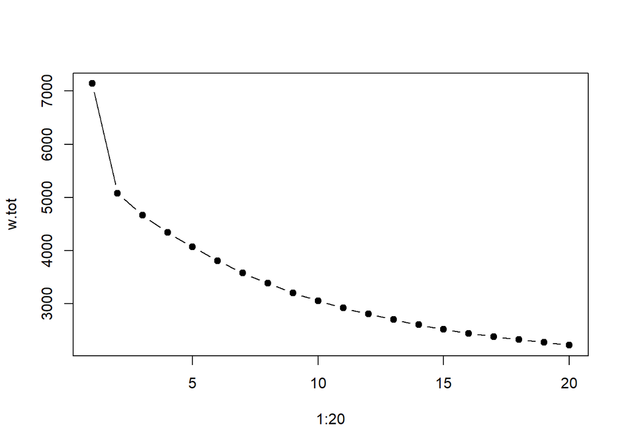

```r
# within function from slides
within = function(d,clust){
  w=numeric(length(unique(clust)))
  for(i in sort(unique(clust))){
    members = d[clust==i, , drop=F]
    centroid = apply(members,2,mean)
    members.diff = sweep(members,2,centroid)
    w[i] = sum(members.diff^2)
  }
  return(w)
}

# between function from slides
between = function(d,clust){
  b=0
  total.mean = apply(d,2,mean)
  for(i in sort(unique(clust))){
    members = d[clust==i, , drop=F]
    centroid = apply(members,2,mean)
    b = b + nrow(members) * sum((centroid-total.mean)^2)
  }
  return(b)
}

# plot within and between ss for ward hclust
w.tot = numeric(20)
btw = numeric(20)
for(k in 1:20){
  clust = cutree(hc.ward, k=k)
  w = within(whs.data.scaled, clust)
  w.tot[k] = sum(w)
  btw[k] = between(whs.data.scaled, clust)
}
plot(1:20, w.tot, pch=19, type="b")
```

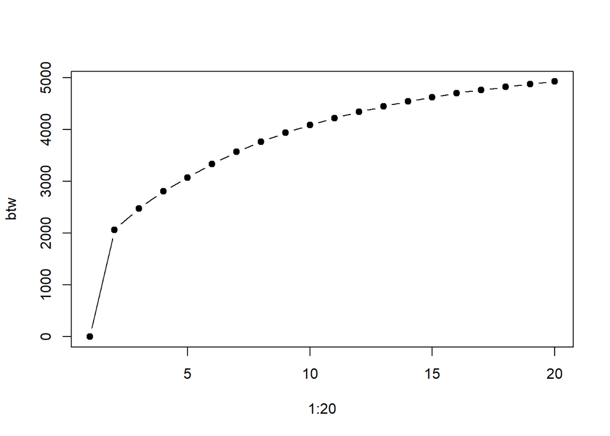

```r
plot(1:20, btw, pch=19, type="b")
```

We see very similar results for Total Within and Between SS for Ward hclust() as seen above for K-means. For Total Within SS, we see the greatest drop in SS at K=2, but the value is close to 5000 (K-means at K=2 had SS_tot.within drop to slighly below 5000), and the SS_within decreases steadily for each K after 2. For Between SS we see the SS increase the most at K=2 and steadily increase for each K after, just like the K-means graph. This makes sense since both approaches aim to calculate Total Within and Between SS on the same dataset and get similar results.

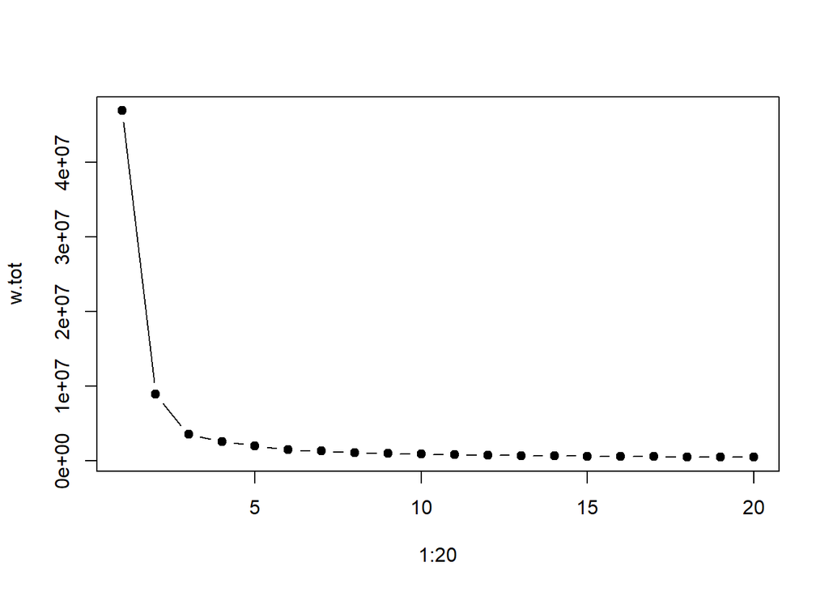

```r
# Total Within and Between SS for Quakes using hclust() and cutree()
# plot within and between ss for ward hclust
hc.ward = hclust(dist(quakes), method="ward.D2")

w.tot = numeric(20)
btw = numeric(20)
for(k in 1:20){
  clust = cutree(hc.ward, k=k)
  w = within(quakes, clust)
  w.tot[k] = sum(w)
  btw[k] = between(quakes, clust)
}
plot(1:20, w.tot, pch=19, type="b")
```

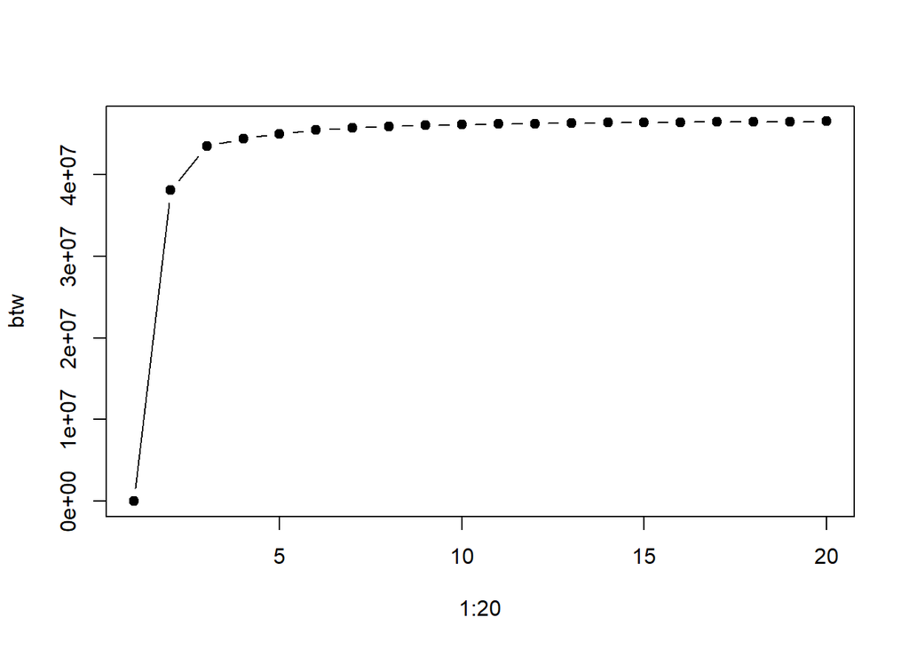

```r
plot(1:20, btw, pch=19, type="b")
```

# Problem 4: Brute force randomization in hierarchical clustering (15 points)

Compare distribution of the heights of the clusters defined by `hclust` with Ward’s clustering of Euclidean distance between countries in scaled WHS dataset and those obtained by applying the same approach to the distances calculated on randomly permuted WHS dataset as illustrated in the lecture slides. Discuss whether results of such brute force randomization are supportive of presence of unusually close or distant sets of observations within WHS data.

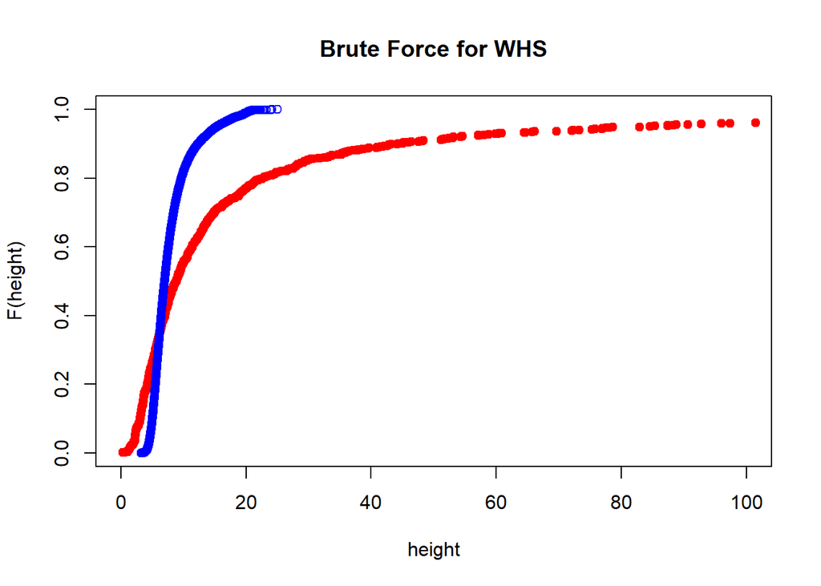

```r
# code adatped by Brute Force slides
ori.heights = hc.ward$height
rnd.heights = numeric()
for(i.sim in 1:100){
  data.rnd = apply(whs.data.scaled, 2, sample)
  hc.rnd = hclust(dist(data.rnd), method="ward.D2")
  rnd.heights = c(rnd.heights, hc.rnd$height)
}
plot(ori.heights, rank(ori.heights)/length(ori.heights), col="red", xlab="height", ylab="F(height)", pch=19, main="Brute Force for WHS", xlim=c(0,100))
points(rnd.heights, rank(rnd.heights)/length(rnd.heights), col="blue")
```

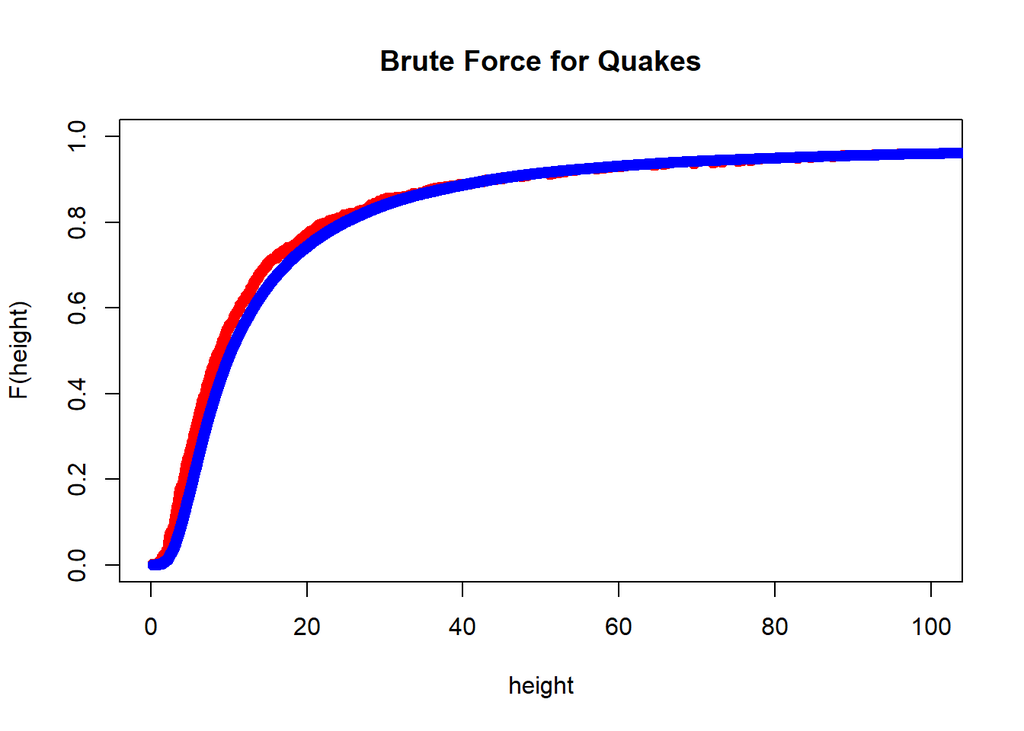

```r
# brute force for Quakes data
hc.ward = hclust(dist(quakes), method="ward.D2")

ori.heights = hc.ward$height
rnd.heights = numeric()
for(i.sim in 1:100){
  data.rnd = apply(quakes, 2, sample)
  hc.rnd = hclust(dist(data.rnd), method="ward.D2")
  rnd.heights = c(rnd.heights, hc.rnd$height)
}
plot(ori.heights, rank(ori.heights)/length(ori.heights), col="red", xlab="height", ylab="F(height)", pch=19, main="Brute Force for Quakes", xlim=c(0,100))
points(rnd.heights, rank(rnd.heights)/length(rnd.heights), col="blue")
```